# ST 558 Project 3: Business Analysis Report

Suyog Dharmadhikari; Bennett McAuley

2022-11-02

## Introduction

The goal of this report is to create and compare predictive models using [Online News Popularity](https://archive.ics.uci.edu/ml/datasets/Online+News+Popularity) data from the UCI Machine Learning Repository.

This data contains information about articles published by Mashable over a period of two years–specifically the statistics associated with them.

The purpose of this analysis is to use linear regression and ensemble tree-based methods to predict the number of `shares`–our target variable–subset by data channel. For more details about these methods, see the *Modeling* section.

According to the data description, there are 39,797 observations and 61 variables present. 58 of them are predictors, but using all of them would be inefficient and show glaring redundancies. Instead, the ones that will be used were chosen intuitively–what might encourage a user to share an article, what underlying forces may influence them, and what would make for good exploratory analysis:

1. `average_token_length` - Average length of the words in the content
2. `avg_negative_polarity` - Avg. polarity of negative words
3. `global_rate_positive_words` - Rate of positive words in the content
4. `global_sentiment_polarity` - Text sentiment polarity
5. `global_subjectivity` - Text subjectivity
6. `is_weekend` - Was the article published on the weekend?
7. `kw_avg_max` - Best keyword (avg. shares)
8. `kw_avg_min` - Worst Keyword (avg. shares)
9. `kw_max_max` - Best keyword (max shares)
10. `kw_min_min` - Worst keyword (min shares)
11. `n_non_stop_words` - Rate of non-stop words in the content
12. `n_tokens_content` - Number of words in the content
13. `n_tokens_title` - Number of words in the title
14. `n_unique_tokens` - Rate of unique words in the content
15. `num_hrefs` - Number of links
16. `num_imgs` - Number of images
17. `num_self_hrefs` - Number of links to other articles published by Mashable
18. `num_videos` - Number of videos
19. `self_reference_avg_shares` - Avg. shares of referenced articles in Mashable
20. `title_sentiment_polarity` - Title polarity
21. `weekday_is_monday` - Was the article published on a Monday?
22. `weekday_is_tuesday` - Was the article published on a Tuesday?
23. `weekday_is_wednesday` - Was the article published on a Wednesday?
24. `weekday_is_thursday` - Was the article published on a Thursday?
25. `weekday_is_friday` - Was the article published on a Friday?
26. `weekday_is_saturday` - Was the article published on a Saturday?
27. `weekday_is_sunday` - Was the article published on a Sunday?

Which we store in a vector for fast retrieval:

```r
news.vars <- c('n_tokens_title', 'n_tokens_content', 'n_non_stop_words', 'num_hrefs',
               'num_self_hrefs', 'num_imgs', 'num_videos', 'average_token_length',
               'kw_max_max', 'kw_min_min', 'kw_avg_max', 'kw_avg_min',
               'self_reference_avg_sharess','is_weekend', 'global_subjectivity', 'global_sentiment_polarity',
               'global_rate_positive_words', 'avg_negative_polarity', 'n_unique_tokens', 'title_sentiment_polarity',
               'weekday_is_sunday', 'weekday_is_monday', 'weekday_is_tuesday', 'weekday_is_wednesday',
               'weekday_is_thursday', 'weekday_is_friday', 'weekday_is_saturday'
               )
```

## The Data

For this analysis, we will consider a single source for the data channel. In other words, we subset the data to the *Business* channel.

So, we read in the data, perform the filter, and convert `is_weekend` into a binary factor:

```r
news <- read_csv("OnlineNewsPopularity.csv")
fltr <- paste0("data_channel_is_", params$channel)

news.tbl <- news %>% filter(get(fltr) == 1) %>%
  select(all_of(news.vars), shares) %>%
  mutate(is_weekend = as.factor(is_weekend))

head(news.tbl)
```

```
## # A tibble: 6 × 28
##   n_toke…¹ n_tok…² n_non…³ num_h…⁴ num_s…⁵ num_i…⁶ num_v…⁷ avera…⁸ kw_ma…⁹ kw_mi…˟ kw_av…˟ kw_av…˟
##      <dbl>   <dbl>   <dbl>   <dbl>   <dbl>   <dbl>   <dbl>   <dbl>   <dbl>   <dbl>   <dbl>   <dbl>
## 1        9     255    1.00       3       1       1       0    4.91       0       0       0       0
## 2        9     211    1.00       3       1       1       0    4.39       0       0       0       0
## 3        8     397    1.00      11       0       1       0    5.45       0       0       0       0
## 4       13     244    1.00       3       2       1       0    4.42       0       0       0       0
## 5       11     723    1.00      18       1       1       0    5.23       0       0       0       0
## 6        8     708    1.00       8       3       1       1    4.62       0       0       0       0
## # … with 16 more variables: self_reference_avg_sharess <dbl>, is_weekend <fct>,
## #   global_subjectivity <dbl>, global_sentiment_polarity <dbl>, global_rate_positive_words <dbl>,
## #   avg_negative_polarity <dbl>, n_unique_tokens <dbl>, title_sentiment_polarity <dbl>,
## #   weekday_is_sunday <dbl>, weekday_is_monday <dbl>, weekday_is_tuesday <dbl>,
## #   weekday_is_wednesday <dbl>, weekday_is_thursday <dbl>, weekday_is_friday <dbl>,
## #   weekday_is_saturday <dbl>, shares <dbl>, and abbreviated variable names ¹n_tokens_title,
## #   ²n_tokens_content, ³n_non_stop_words, ⁴num_hrefs, ⁵num_self_hrefs, ⁶num_imgs, ⁷num_videos, …
```

## Summarizations

Now that our data has been manipulated and filtered, we can perform a simple EDA.

### Summary Statistics

First and foremost, we want to know what range of values we might expect when predicting for `shares`. The following table shows basic summary statistics about the variable:

```r
s <- summary(news.tbl$shares)

tibble(var = 'shares', min = s[1], max = s[6], mean = s[3], stddev = sd(news.tbl$shares))
```

```
## # A tibble: 1 × 5
##   var    min     max     mean    stddev
##   <chr>  <table> <table> <table>  <dbl>
## 1 shares 1       690400  1400    15046.
```

If the maximum is tremendously larger in scale than the mean, then it is very likely an outlier. If the standard deviation is larger than the mean, then the number of shares varies greatly. Furthermore, the higher it is, the more disperse they are from the mean. The inverse also applies for a smaller standard deviation (i.e. the smaller, the less disperse).

It would also be good to know relationships between some of the variables present–and not just to `shares`. Observe the following correlation matrix of variables related to content sentiment. A value of 0 indicates no correlation and 1 indicates perfect correlation. The closer a value is to 1(+/-), the stronger the relationship is. The closer to 0, the weaker.

```r
c <- news.tbl %>%
  select(avg_negative_polarity,
         global_rate_positive_words,
         global_sentiment_polarity,
         global_subjectivity,
         shares)

round(cor(c),2)
```

```
##                            avg_negative_polarity global_rate_positive_words
## avg_negative_polarity                       1.00                      -0.02
## global_rate_positive_words                 -0.02                       1.00
## global_sentiment_polarity                   0.28                       0.59
## global_subjectivity                        -0.30                       0.29
## shares                                     -0.06                       0.02
##                            global_sentiment_polarity global_subjectivity shares
## avg_negative_polarity                           0.28               -0.30  -0.06
## global_rate_positive_words                      0.59                0.29   0.02
## global_sentiment_polarity                       1.00                0.30  -0.01
## global_subjectivity                             0.30                1.00   0.05
## shares                                         -0.01                0.05   1.00
```

### Plots

For visual analysis, we first construct a density plot to compare the densities of `shares` between the weekend (`is_weekend = 1`) and weekdays (`is_weekend = 0`). Observe the patterns generated for similarities and/or differences.

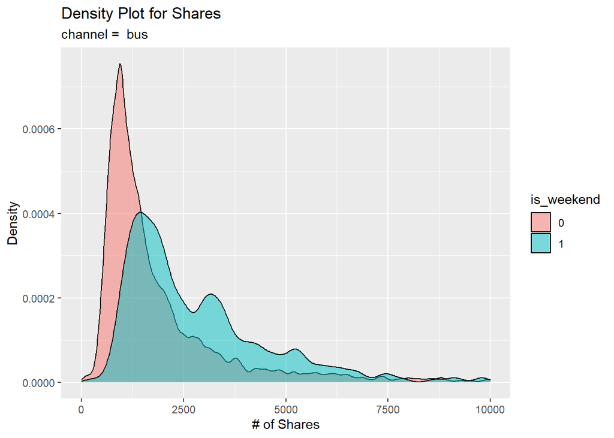

```r
g <- ggplot(data = news.tbl, aes(x = shares))

g + geom_density(adjust = 0.5, alpha = 0.5, aes(fill = is_weekend)) +
  xlim(0, 10000) +
  scale_y_continuous(labels = scales::comma) +
  labs(title = "Density Plot for Shares",
       subtitle = paste("channel = ", params$channel),
       x = "# of Shares",
       y = "Density")
```

The second visual is a scatterplot with a trend line. The number of words in the content is on the x-axis and the rate of unique words on the y-axis. If the data points and trend line show an upward trend, then articles with more words tend to have a larger rate of unique ones. If there is a downward trend, then articles with more words tend to have a smaller rate of unique ones.

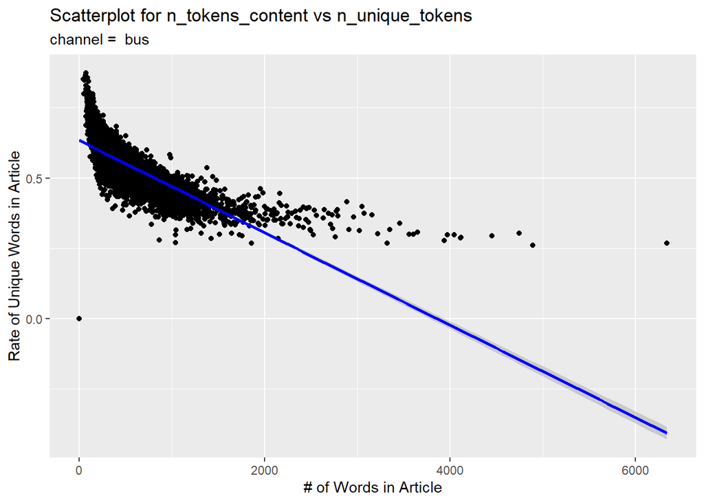

```r
p <- ggplot(news.tbl, aes(x = n_tokens_content, y = n_unique_tokens))

p + geom_point() +
  geom_smooth(method = glm, col = "Blue") +
  labs(title = "Scatterplot for n_tokens_content vs n_unique_tokens",
       subtitle = paste("channel = ", params$channel),
       x = "# of Words in Article",
       y = "Rate of Unique Words in Article")
```

This subsequent bar plot shows a comparison between the total number of articles published on each day of the week and the total shares of those articles. Observe any interestingly sized columns that one might think would be higher or lower than others. Articles published on which day tend to get shared the most? Which one gets the least?

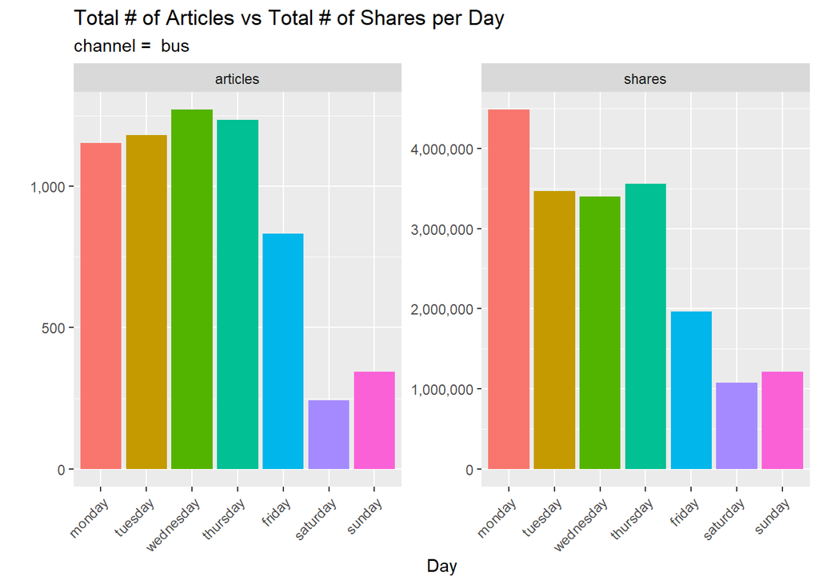

```r
plt <- news.tbl %>% pivot_longer(cols = starts_with("weekday_is_"),
               names_to = "day",
               names_prefix = "weekday_is_",
               names_transform = as.factor,
               values_to = "count") %>%
  filter(count == 1) %>%
  select(-count, -starts_with("weekday_is_"))

#Reordering days
plt$day <- factor(plt$day,
    levels = c("monday", "tuesday", "wednesday", "thursday", "friday", "saturday", "sunday"))


plt <- plt %>%
  select(day, shares) %>%
  group_by(day) %>%
  summarise(articles = n(), shares = sum(shares))

plt <- reshape2::melt(plt, id.vars = c("day"))

p <- ggplot(plt, aes(x = day, y = value, fill = day))

p + geom_col() +
  facet_wrap(vars(variable), scales = "free") +
  scale_y_continuous(labels = scales::comma) +
  guides(x = guide_axis(angle = 45), fill = "none") +
  labs(title = "Total # of Articles vs Total # of Shares per Day",
       subtitle = paste("channel = ", params$channel),
       x = "Day",
       y = '')
```

## Modeling

The goal now is to create models for predicting the number of `shares` using linear regression and ensemble trees. Before that, the data is split into a training (70%) and test (30%) set.

```r
i <- createDataPartition(news.tbl[[1]], p = 0.7, list = FALSE)

train <- news.tbl[i,]
test <- news.tbl[-i,]
```

### Linear Regression

#### *Model #2*

The `regsubsets` function is called, and the summary is returned to grab the models of $n$ terms that have the optimal values for $R^2$, Mallows’ Cp, and BIC. As performance will vary, the mode value between the three is chosen as the ‘best’.

```r
backVars <- regsubsets(shares ~ ., train, method = "backward")
backSumm <- summary(backVars, all.best = FALSE)

met <- c(R2 = which.max(backSumm$rsq),
     Cp = which.min(backSumm$cp),
     BIC = which.min(backSumm$bic)
)

M <- which.max(tabulate(met))
```

The most frequent number is 8. The variables present in this size model are:

```r
coef(backVars, M)
```

```
##                (Intercept)                  num_hrefs                   num_imgs
##               4.792812e+03               8.649874e+01               1.434232e+02
##                 num_videos       average_token_length                 kw_avg_min
##               1.600948e+02              -2.114433e+03               2.510389e+00
## self_reference_avg_sharess      avg_negative_polarity            n_unique_tokens
##               4.920076e-02              -8.574227e+03               7.451174e+03
```

```r
BackwardFit <- train(shares ~ n_tokens_content + num_hrefs + num_self_hrefs + num_imgs +
                     num_videos + is_weekend + global_rate_positive_words + weekday_is_wednesday,
                    data = train,
                    method = "lm",
                    metric = "Rsquared",
                    preProcess = c("scale"),
                    trControl = trainControl(method = "cv", number = 10))

summary(BackwardFit)
```

```
##
## Call:
## lm(formula = .outcome ~ ., data = dat)
##
## Residuals:
##    Min     1Q Median     3Q    Max
## -21649  -2114  -1632   -693 684057
##
## Coefficients:
##                            Estimate Std. Error t value Pr(>|t|)
## (Intercept)                 2010.51     838.06   2.399  0.01648 *
## n_tokens_content             -59.84     339.55  -0.176  0.86013
## num_hrefs                    383.03     354.41   1.081  0.27986
## num_self_hrefs               165.64     288.12   0.575  0.56538
## num_imgs                     413.07     282.39   1.463  0.14361
## num_videos                   823.88     272.74   3.021  0.00254 **
## is_weekend1                  146.38     276.61   0.529  0.59670
## global_rate_positive_words   170.46     273.79   0.623  0.53359
## weekday_is_wednesday        -145.29     270.70  -0.537  0.59148
## ---
## Signif. codes:  0 '***' 0.001 '**' 0.01 '*' 0.05 '.' 0.1 ' ' 1
##
## Residual standard error: 17670 on 4373 degrees of freedom
## Multiple R-squared:  0.004376,   Adjusted R-squared:  0.002555
## F-statistic: 2.403 on 8 and 4373 DF,  p-value: 0.01386
```

### Boosted Tree Model

Boosting centers around the idea of sequential learning–taking information from preceding iterations as a basis for calculating the current iteration. Boosted trees are ensemble tree models consisting of a group of trees that are built in sequence, including errors from previous trees for predictions.

Boosted trees also have a unique characteristic of *slow* training. This is controlled by $\lambda$, a shrinkage parameter. The two other notable parameters for training a boosted tree are $B$ (the number of times the algorithm performs its procedure; `n.trees` in R) and $d$ (the number of splits; `interaction.depth` in R), both of which can be selected with cross-validation.

For regression, the boosting algorithm proceeds as follows:

1. The predictions are initialized to 0–$\hat{y}(x)=0$
2. The residuals between observed and predicted values are calculated
3. A tree with $d$ splits and $d+1$ terminal nodes is fit using the residuals as the response–denoted by $\hat{y}^b(x)$
4. The overall prediction is updated by recursively adding these pseudo-responses–$\hat{y}(x) +=\lambda\hat{y}^b(x)$
5. Residuals for new predictions are updated
6. Repeat $B$ times

This model is fit using `cv = 10`, and the `train` function will determine the optimal values of the parameters for us.

```r
#Output for this chunk is hidden as it is rather long and does not provide information needed for reporting
boostFit <- train(shares ~ .,
              method = "gbm",
              data = train,
              trControl = trainControl(method = "cv", number = 10))
```

During training, the optimal values for the tuning parameters were found to be:

```r
boostFit$bestTune
```

```
##   n.trees interaction.depth shrinkage n.minobsinnode
## 1      50                 1       0.1             10
```

Since coefficients aren’t interpretable for boosted trees, the calculation of variable importance for the final model is shown instead, in descending order:

```r
varImp(boostFit$finalModel) %>% arrange(desc(Overall))
```

```
##                                 Overall
## kw_avg_min                 411046271538
## self_reference_avg_sharess 244577994037
## avg_negative_polarity      155287858278
## average_token_length        83042283971
## num_videos                  37725604774
## num_imgs                    19913855139
## num_self_hrefs              12102502373
## global_sentiment_polarity    6485025918
## n_tokens_title                        0
## n_tokens_content                      0
## n_non_stop_words                      0
## num_hrefs                             0
## kw_max_max                            0
## kw_min_min                            0
## kw_avg_max                            0
## is_weekend1                           0
## global_subjectivity                   0
## global_rate_positive_words            0
## n_unique_tokens                       0
## title_sentiment_polarity              0
## weekday_is_sunday                     0
## weekday_is_monday                     0
## weekday_is_tuesday                    0
## weekday_is_wednesday                  0
## weekday_is_thursday                   0
## weekday_is_friday                     0
## weekday_is_saturday                   0
```